# Final Project

24 March 2023

## R Markdown

**Research Question**: Is listening to music an effective form of dealing with mental health issues?

Immensely prevalent amongst college students, this population struggles with their mental health. The stressors of college and other life events take a toll on their mental health. The topic of combating symptoms of mental health has historically always been met with a plethora of forms of psychological care and medication, all of which having a substantial amount of research behind the work to support that these are immensely helpful methods. Not everyone is capable of affording this level of treatment and may choose to opt for less expensive, more accessible options. For some folks, music is that option. Music therapy, or MT, is the use of music to improve an individual’s stress, mood, and overall mental health. MT is recognized as an evidence-based practice, using music as a catalyst for “happy” hormones. Approaching this topic is difficult due to there not being many studies about the association between mental health and music, or if this association is definitely proven to be able to replace other forms of therapy while offering the same effects. However, music does have an effect on people in a plethora of ways. Music acts as a mood changer. Depending on the genre that the person decides to listen to, varying from one organization to the next, music possesses therapeutic effects that impact the individual’s mood in addition to the brain on different levels.

## Literature Review

**Music and People with Tendencies to Depression**

As depression is often associated with feeling apathetic and indifferent to improving one’s state of mind or mood, Garrido and Schubert attempt to direct a study where students listen to their own selection of a song that would presumably make them sad in order to investigate whether or not music has an influence on their feelings. Through their findings, the results indicated that listening to “sad” music did significantly increase feelings of depression of those who already had a tendency to such emotions. They also found that those with a tendency to depression gravitated towards music with sad sentiments/melodies, despite the knowingly negative influence it had on their mental and emotional wellbeing.

Garrido and Schubert provide a theoretical framework surrounding the effects of music on those who struggle with depression. With their understanding of how music can shape the mood of depressed individuals, we can further elaborate on how music can affect those with or without other disorders. Upon their research, we can also dive into the realms of mood regulation, which is closely attached to music therapy and strategies that are effective in improving one’s emotional and mental state. Overall, their study and findings are important in recognizing that music is a powerful force, that can either help or hinder individual condition based on the background of the person and the context of their treatment or diagnosis.

**Emotion Modulation in Psychiatric Patients Through Music**

Gebhardt, Kunkel, and von Goergi (hereinafter referred to as “the researchers”) conducted a study where they explored the differences in the use of music by a population of psychiatric patients and a group of healthy participants. They found that those with existing mental disorders treated music as a way to regulate their moods and emotions, more especially than their counterparts. The patients used music as a way to solve cognitive problems and to avoid any stimulants that would negatively affect their current state. By the end of the researchers’ study, the results indicated that music was heightened to a level of more use depending on the severity of the individual’s disorder. In other words, those with a lower level of general functioning used music as a way to modulate any negative emotions that would otherwise arise without the music.

By looking into the impact of music on individuals across multiple disorders as well as those who are seemingly mentally well, we can study the atomistic nature of music and how different it can influence someone in various ways. Our dataset contains self-reported levels of mental health struggles, such as anxiety, depression, insomnia, and OCD. These responses can aid our analysis of how music can either aid or inhibit one’s attempt at bettering their emotional state. Furthermore, the survey contains a breakdown of specific genres, which can strengthen our understanding of how certain sounds or musical styles can help certain disorders (or if it is completely subjective and dependent on the individual themself).

**Rising to a New Paradigm: Infusing Health and Wellness into the Music Curriculum**

Musicians’ wellbeing and physical health are often disregarded, in comparison to athletes who are more doted on and concerned about by the general public. Like everyone from all sorts of backgrounds, musicians deal with both physical and physiological health struggles that can negatively affect their lives. Pierce argues that designing a person-centered approach to the music curriculum, which would include a wellness training program, would create a fundamental change within the world of music teaching as well as the musicians’ everyday life. Their research gathered data on how a large percentage of musicians experienced physical injuries and/or mental health issues that were impactful enough to endanger themselves and their livelihood. One being “hearing loss,” which had a detrimental effect on the individuals’ mental wellbeing as well as their physical health. Pierce also found that those who decide to go down the professional musician career path were especially susceptible to physiological problems.

Pierce’s research can aid our understanding of how music is more than a leisure activity, and how music is its own whole world in and of itself. Professional musicians who are predominantly occupied with (evidently) music struggle with mental health issues, which can be suppressed by implementing more focus on each individual and providing a nurturing environment for all, rather than a competitive one of that nature. Pierce’s line of reasoning and their main argument can help better the mental wellbeing of all, not just musicians. With their findings, we can further grasp how important mental health awareness is and how music is a great starting point in reaching better places on a holistic health level.

**Mental health and music engagement: review, framework, and guidelines for future studies**

Immensely prevalent amongst college students, this population struggles with their mental health. The stressors of life take a toll on their mental health. The topic of combating symptoms of mental health has been met with the questions of if music can be an effective method. Approaching this topic is difficult due to there not being many studies about the association between mental health and music. Those pieces we have access to now have this issue of having small populations participating in the study in addition to methodology limitations. The researchers did not have access to needed resources and tools to document information.

Gustavson et al tackle the issue by outlining the necessary steps needed to approach these research questions due to the lack of research regarding this music as a combative method. Firstly, they start by outlining the common strengths and weaknesses of previous research. Secondly, they create a theoretical model to aid future researchers in that describes the importance of specific factors when discussing the relationship between the two aspects such as genetic influences, environmental factors, the effectiveness of treatment, and how the brain is impacted. Lastly, they describe data they received from previous research, emphasizing neuroimaging and other health records to aid in chemical changes. This information will be useful for our initial approach to our research question. It sets a solid foundation for us to work with when looking for data sets and breaking down the information.

**Music, Mental Health, and Immunity**

In previous research surrounding music as a form of therapy, the information usually centers around the acknowledgement of a population experiencing a mental health crisis. This is paired with the exploration of methods like music to improve individuals’ moods. Some research argues that this form of therapy is an ideal substitution / replacement for folks due to it being more affordable. Medications and other psychological care can be expensive. Music therapy provides a great method of combating symptoms of mental illnesses, but how does it impact your immune system? Therapy is usually centered around understanding what chemicals are lacking and being prescribed the necessary medication to modulate their immune systems. The issue with medication is that it could have a plethora of side effects and even worsen folks symptoms. With that being said, it poses the question: does music therapy impact your biology, specifically, your chemical balances in similar ways that medicine can do to achieve better overall moods?

Livinia Rebecchini explores the biological components of music therapy. They outline the intervention methods of music therapy, specifically how different music genres impact different parts of the brain. There are specific points of inflammation and immune responses that are impacted by music we listen to. In turn, the brain increases and decreases different hormones inside the body. This data could play a specific role in our research by outlining what music is most effective for folks by determining which genres can supply the needed hormones for folks.

## References

Garrido, S., & Schubert, E. (2015). Music and people with tendencies to depression. Music Perception, 32(4), 313–321. https://doi.org/10.1525/mp.2015.32.4.313

Gebhardt, S., Kunkel, M., & Georgi, R. von. (2012). Emotion modulation in psychiatric patients through music. Music Perception, 31(5), 485–493. https://doi.org/10.1525/mp.2014.31.5.485

Gustavson, D. E., Coleman, P. L., Iversen, J. R., Maes, H. H., Gordon, R. L., & Lense, M. D. (2021). Mental Health and Music engagement: Review, Framework, and Guidelines for Future Studies. https://doi.org/10.31234/osf.io/erv9c

Pierce. (2012). Rising to a new paradigm: Infusing health and wellness into the music curriculum. Philosophy of Music Education Review, 20(2), 154. https://doi.org/10.2979/philmusieducrevi.20.2.154

Rebecchini, L. (2021). Music, mental health, and immunity. Brain, Behavior, & Immunity - Health, 18, 100374. https://doi.org/10.1016/j.bbih.2021.100374

## Data & Methods

For our project, we intend to analyze an online survey that contains self-reported information across different attributes. Most notably, the columns we will be focusing on revolve around the levels of depression and anxiety the respondents experience as well as their background (age, favorite music genre, whether or not they believe music has an effect on them). We will compare the depression and anxiety levels using plot functions in order to visualize the differences between the two. After drawing comparisons from these plots, we will run an OLS regression model between the following two variables: Age and Depression/Anixety. Our goal here is to model a relationship between the two variables.

## Limitations

Before delving into our analysis, we must note a few constraints that come along with the dataset we are using. Since the depression and anxiety levels are self-reported, there is no way to distinguish whether or not the respondents have been clinically diagnosed with these disorders. The intention behind the survey was to identify a correlation between one’s musical preferences and their mental health, in the lens of music therapy. However, we will simply focus on the “therapeutic effects” of music, rather than the idea of music therapy as it poses more complications and defining what exactly the therapy entails is unclear when working with the dataset. With these limitations into account, we aim to explore the relationship between the following variables: depression/anxiety levels and music taste/age.

## Analysis

Below is a histogram displaying the frequency of each depression level response. We can see that the partitioned levels (zero to low and above average) are similar across the board. Majority of the respondents indicated that they either do not experience, somewhat experience, or do regularly experience depression.

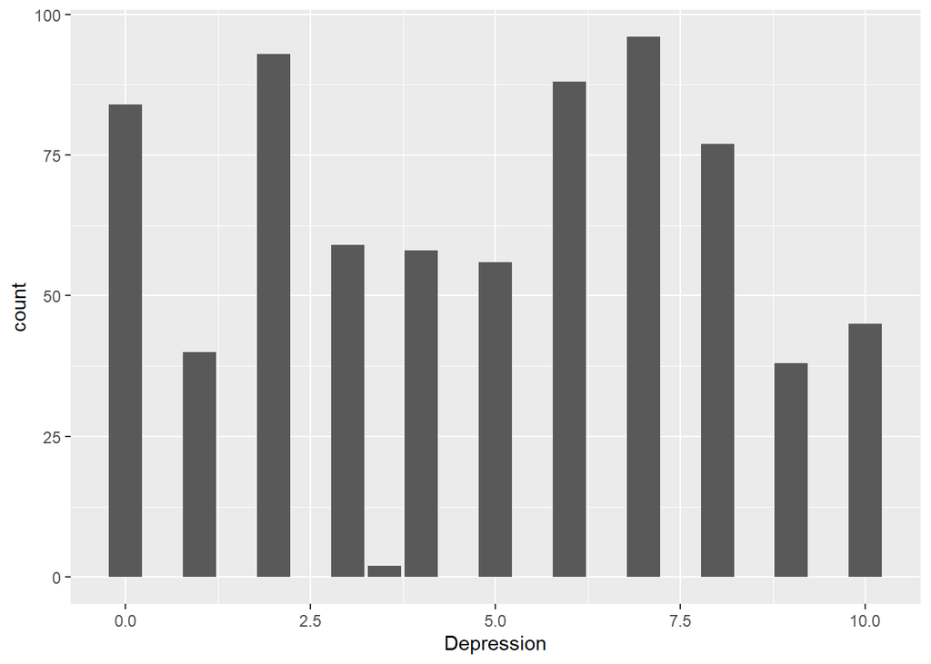

Below is a histogram displaying the frequency of anxiety levels for all respondents. We can see that most of the subjects experience anxiety regularly.

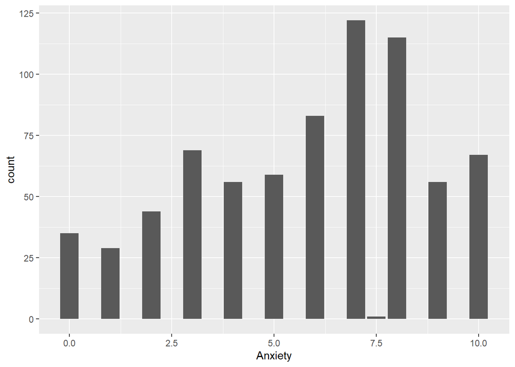

These boxplots display the distribution of anxiety levels across the different frequencies in which the respondents listen (or do not listen) to Classical music. We can see that those who either never or sometimes listen to Classical, reported higher anxiety levels

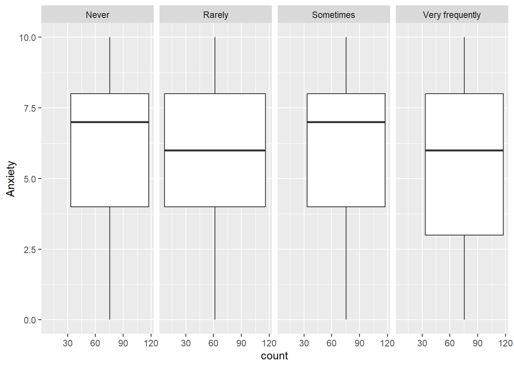

These boxplots display the distribution of anxiety levels across the different frequencies in which the respondents listen (or do not listen) to Metal music. We can see that those who listen to Metal either rarely or sometimes, reported higher anxiety levels.

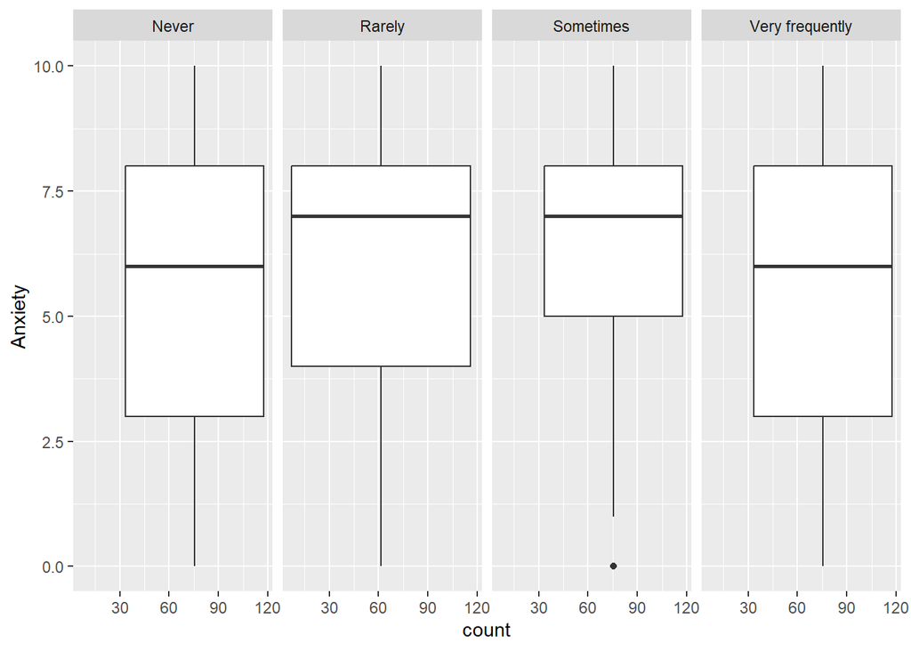

These boxplots display the distribution of anxiety levels across the different frequencies in which the respondents listen (or do not listen) to the EDM genre. We can see that those who rarely listen to EDM reported higher anxiety levels.

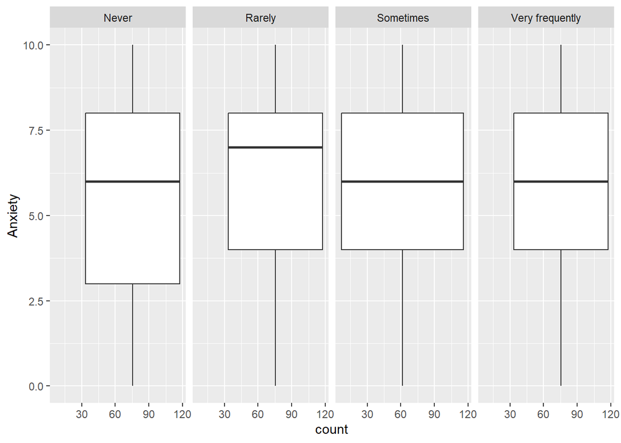

These boxplots display the distribution of depression levels across the different frequencies in which the respondents listen (or do not listen) to Classical music. We can see that those who listen to Classical sometimes reported higher depression levels.

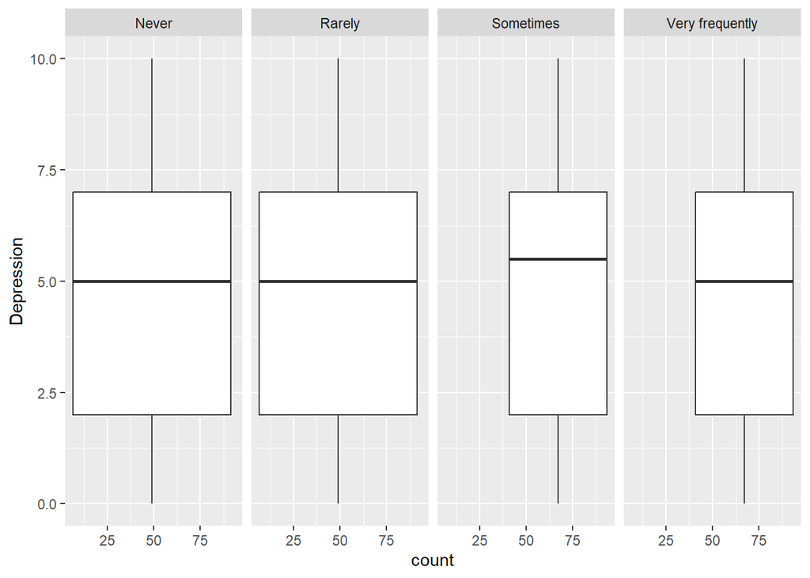

These boxplots display the distribution of depression levels across the different frequencies in which the respondents listen (or do not listen) to Metal music. We can see that those who listen to Metal either sometimes or very frequently, reported higher depression levels.

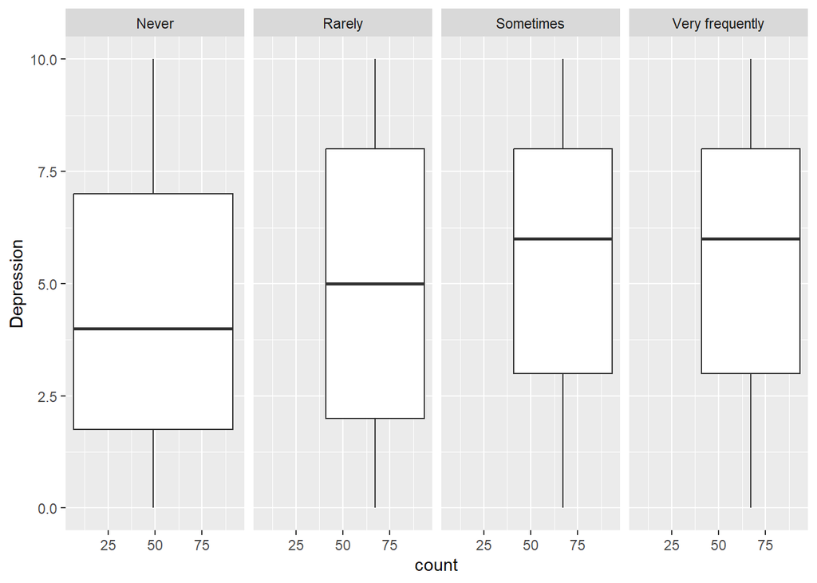

These boxplots display the distribution of depression levels across the different frequencies in which the respondents listen (or do not listen) to the EDM genre. We can see that those who listen to EDM rarely, sometimes, and very frequently reported higher depression levels.

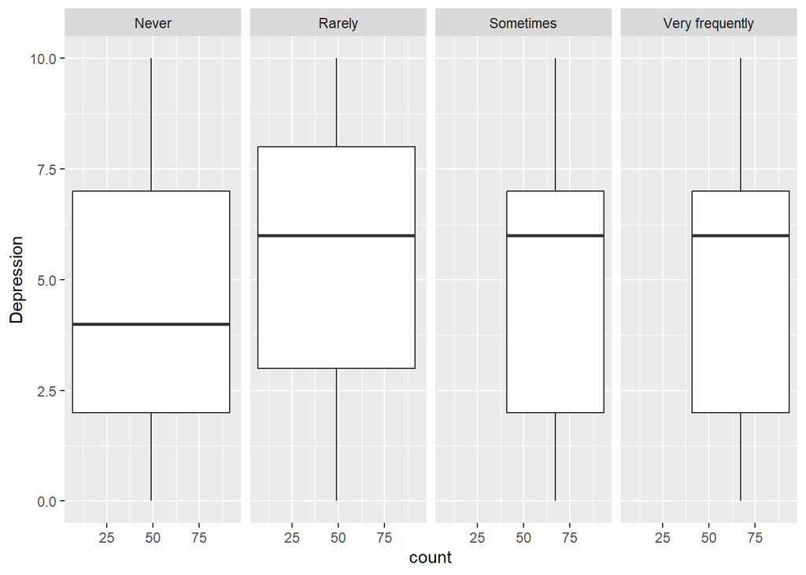

The differing boxplot results indicate that depression and anxiety levels are independent of musical preference. We can infer that the respondents’ self-reported mental health is dependent on each individual experience and background, rather than the music they decide to listen to. However, it is important to note that some individuals gravitate towards certain genres that may facilitate their existing emotions.

Below is a scatterplot representation of the respondents’ ages and their self-reported depression levels. As the line of best fit trends downwards, we can see that there is a negative correlation between the two variables. Those who fall under the age range of teens to mid-20s reported higher levels of depression, in comparison to the older respondents.

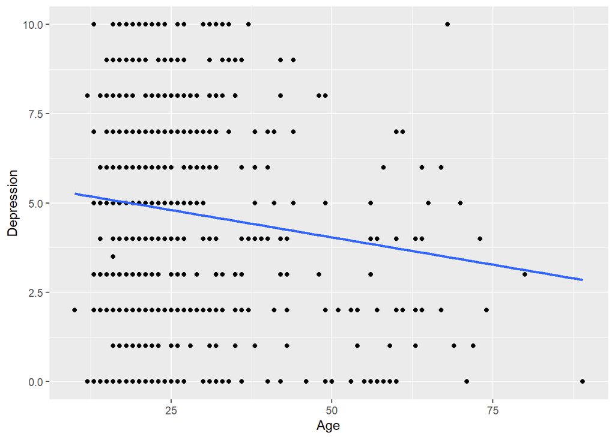

```
##
## Call:
## lm(formula = Depression ~ Age, data = cleaned)
##
## Residuals:
##     Min      1Q  Median      3Q     Max
## -5.2022 -2.7702  0.1339  2.2562  6.5090
##
## Coefficients:
##              Estimate Std. Error t value Pr(>|t|)
## (Intercept)  5.568880   0.257460  21.630  < 2e-16 ***
## Age         -0.030557   0.009216  -3.316 0.000959 ***
## ---
## Signif. codes:  0 '***' 0.001 '**' 0.01 '*' 0.05 '.' 0.1 ' ' 1
##
## Residual standard error: 3.01 on 733 degrees of freedom
##   (1 observation deleted due to missingness)
## Multiple R-squared:  0.01478,    Adjusted R-squared:  0.01343
## F-statistic: 10.99 on 1 and 733 DF,  p-value: 0.0009588
```

Below is a scatterplot representation of the respondents’ ages and their self-reported anxiety levels. As the line of best fit trends downwards, we can see that there is a negative correlation between the two variables. Similar to the depression graph, those who fall under the age range of teens to mid-20s reported higher levels of anxiety, in comparison to the older respondents.

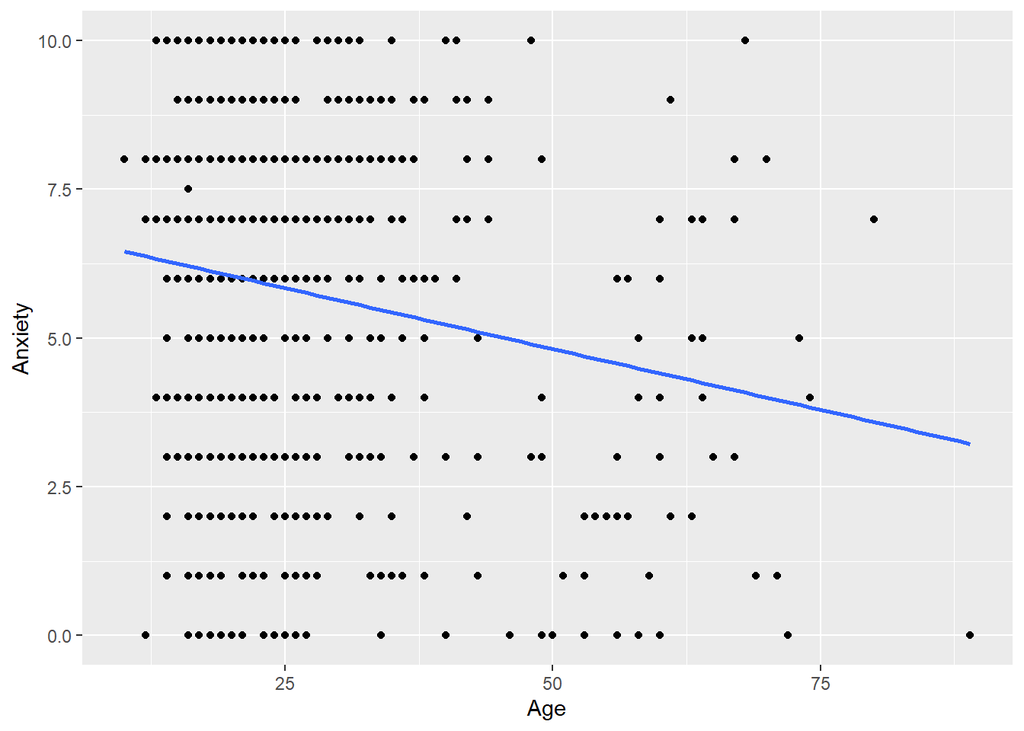

```
##
## Call:
## lm(formula = Anxiety ~ Age, data = cleaned)
##
## Residuals:
##     Min      1Q  Median      3Q     Max
## -6.3738 -2.1487  0.6671  1.9945  5.9179
##
## Coefficients:
##              Estimate Std. Error t value Pr(>|t|)
## (Intercept)  6.864883   0.235278  29.178  < 2e-16 ***
## Age         -0.040923   0.008422  -4.859 1.44e-06 ***
## ---
## Signif. codes:  0 '***' 0.001 '**' 0.01 '*' 0.05 '.' 0.1 ' ' 1
##
## Residual standard error: 2.75 on 733 degrees of freedom
##   (1 observation deleted due to missingness)
## Multiple R-squared:  0.03121,    Adjusted R-squared:  0.02989
## F-statistic: 23.61 on 1 and 733 DF,  p-value: 1.441e-06
```